# Comparing delta N from normal linear model with delta N from log-linear Poisson model

Petr Keil

2025-12-22

This is a script created by Petr Keil to check if we would get the same spatial pattern of `delta_N` from a **normal linear model** (as described in the methods):

`lm(N ~ year)`

or from a **generalized linear model with Poisson errors and log link**:

`glm(N ~ year, family="poisson")`.

This is all an ad-hoc check. To make this fast, we didn’t do a full Bayesian inference here. We simply took the median `N` values (abundance) from the Bayesian model and run `lm()` and `glm()` on them.

In addition, we also compared `delta_N` values obtained from `lm()` and `glm()` with `delta_N` from the mixed effect model. In the latter we expect the effect of shrinkage, which is indeed what we found.

# 1 Load libraries

```r
rm(list=ls())

library(sf)
library(terra)
library(mgcv)
library(geodata)
library(rnaturalearth)
library(tidyverse)
library(randomForest)
library(psych)
library(forcats)
library(gridExtra)
```

```r
# read list of summary files for all species
filelist <- list.files(path = "../summary_models")

# example species
filelist[10]
```

```
## [1] "summary_American Bittern.rds"
```

# 2 Stacking route x year matrices for species together

Here we extract the median estimated abundance (N) time series at each BBS route for each species, checks if the species has converged, and then for each route the scripts adds all the species’ abundances together. The result is a site by year matrix with total abundances per site and time step.

```r
# empty conatiner for the site by year abundance matrix:
Nmat.sum <- matrix(0, nrow=1033, ncol = 35)
# initialize counter (to count total number of converged species)
counter <- 0

# main loop through all species
for(filename in filelist)
{
  # read the summary file of the JAGS model
  summ <- readRDS(paste('../summary_models/', filename, sep=''))
  # extracts mean convergence diagnostics
  mean.rhat <- mean(summ$Rhat[1:20])

  # clean species name for nice output
  species <- gsub(".rds", replacement = "", x = filename)
  species <- gsub("summary_", replacement = "", x = species)

  # summary table of the main  parameters
  sm <- summ[c(1:20),c("mean", "sd", "2.5%", "50%", "97.5%", "Rhat")]
  sm <- data.frame(parameter = rownames(sm),
                   mean = round(sm$mean,2),
                   SD = round(sm$sd,2),
                   q2.5 = round(sm$"2.5%",2),
                   q50 = round(sm$"50%", 2),
                   q97.5 = round(sm$"97.5%",2),
                   Rhat = sm$Rhat)

  # has the model converged?
  converged <- max(sm$Rhat, na.rm=T) <= 1.1

  # extract N
  N <- summ[grepl("N", row.names(summ)),]

  # median estimated abundance (N) at each site and year
  Nmat <- matrix(N$"50%", ncol = 35, nrow = 1033, byrow=FALSE)

  # if the model converged for this species, add the abundances to the totals
  # -- this will produce the Nmat.sum matrix which we will analyze below
  if(converged)
  {
    Nmat.sum <- Nmat.sum + Nmat
    counter <- counter + 1
    cat(paste(counter, species, ", "))
  }
}
```

[output not shown]

# 3 Estimate trends (deltas)

Here we subject the `Nmat.sum` matrix (site by year matrix with median estimated abundances summed up for all species) to several models.

Specifically, we estimate:

- `delta_N` - linear temporal trend of N, using `lm()`
- `delta_Npois` - log-linear temporal trend of N, using `glm()` with Poisson errors and log link
- `delta_g` - linear temporal trend of g, using `lm()`
- `delta_r` - linear temporal trend of r, using `lm()`

```r
# empty container for results
trends <- list()

# For each site in the matrix:
for(i in 1:nrow(Nmat.sum))
{
  time <- 1:35
  diff.time <- 2:35

  N <- Nmat.sum[i,] # time series of abundances N_t at a site i
  g <- diff(N) # time series of g_t
  r <- g/N[1:34] # time series of r_t

  # temporal trends
  deltaN <- lm(N~time)$coef[2]
  deltaNpois <- coef(glm(round(N)~time, family="poisson"))[2]
  deltag <- lm(g~diff.time)$coef[2]
  deltar <- lm(r~diff.time)$coef[2]

  # put the trends together
  res <- c(deltaN = unname(deltaN),
           deltaNpois = unname(deltaNpois),
           deltag = unname(deltag),
           deltar = unname(deltar))

  trends[[i]] <- res
}
# collapse the list to a data frame
trends <- data.frame(do.call("rbind", trends))
```

# 4 Comparison of the four metrics

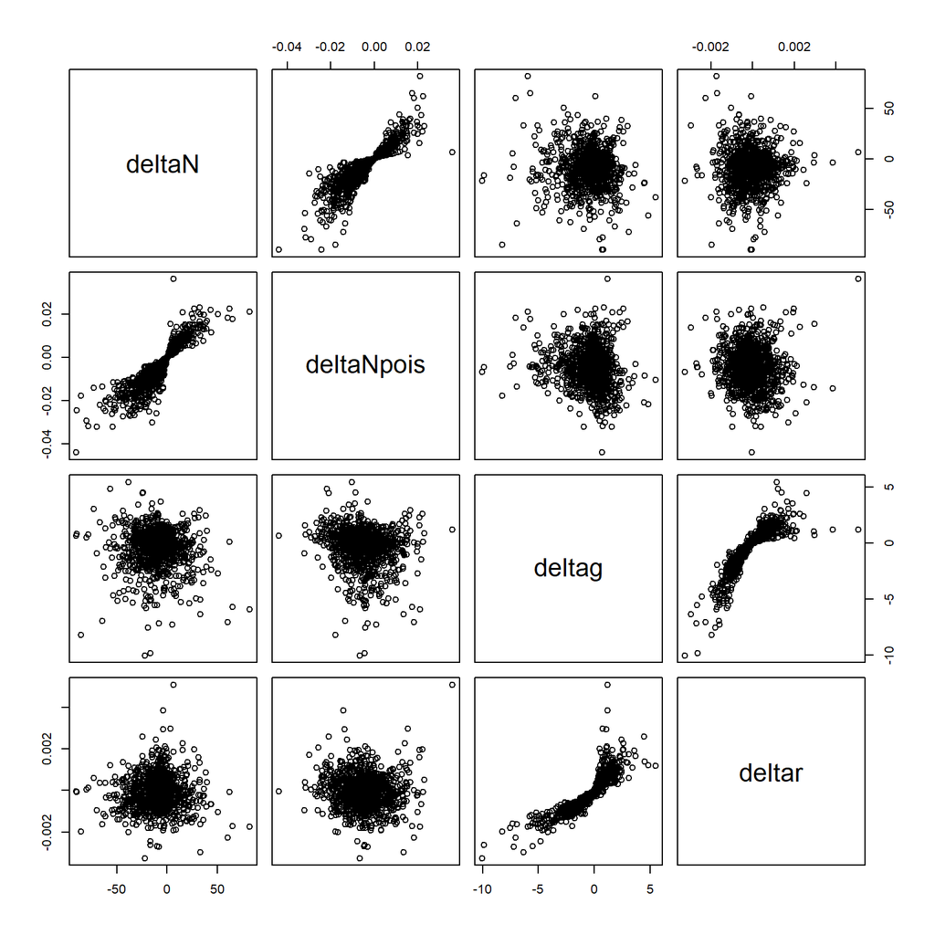

```r
pairs(trends)
```

# 5 Loading the spatial data with trends from the Bayesian mixed model

These are the trends that we actually show and analyze in the paper.

```r
# Load the shapefile with BBS routes
routes <- st_read("../data/routes_shp/routes_selected_lines.shp") %>% arrange(routes)
## get the states polygon
states <-
  ne_states(returnclass = "sf") %>%
  filter(adm0_a3 == "CAN" | adm0_a3 == "USA" | adm0_a3 == "MEX") %>%
  filter(woe_name != "Hawaii") %>%
  st_crop(st_bbox(c(xmin = -165,
                    xmax = -60,
                    ymax = 62,
                    ymin = 16)))
# Load the models' output
for(file in list.files("../mixed_model/outputs/", full.names = T)){
  assign(gsub("^../mixed_model/outputs/|\\.rds$","",file),
         readRDS(file = file))
}
```

# 6 Fit the spatial GAM to all of the trends (deltas)

Here we fit the GAM smoother to all the trend metrics

```r
# extract latitude and longitude of route centroids
coords <- data.frame(st_centroid(routes) %>% st_coordinates() )
```

```r
names(coords) <- c("lon","lat")
routes <- cbind(routes, coords)

##  raw (not smoothed) values of rates from the mixed effect model, as described
# in the methods
routes$delta_N <- overall_N_output$mean$beta1
routes$delta_g <- overall_absg_output$mean$beta1 # note that absg is in fact g
routes$delta_r <- overall_g_output$mean$beta1 # note that g is in fact r (residual notation from early versions)

##  raw (not smoothed) values of rates from simple linear models
routes$delta_N_PK <- trends$deltaN
routes$delta_Npois_PK <- trends$deltaNpois
routes$delta_g_PK <- trends$deltag
routes$delta_r_PK <- trends$deltar

# fit the gam models for the smoothened maps
routes$delta_N_gam <- gam(delta_N ~ s(lon, lat, bs = "gp", k = 100, m = 2),
                          data = routes)$fitted.values
routes$delta_g_gam <- gam(delta_g ~ s(lon, lat, bs = "gp", k = 100, m = 2),
                          data = routes)$fitted.values
routes$delta_r_gam <- gam(delta_r ~ s(lon, lat, bs = "gp", k = 100, m = 2),
                          data = routes)$fitted.values
routes$delta_Npois_gam <- gam(delta_Npois_PK ~ s(lon, lat, bs = "gp", k = 100, m = 2),
                          data = routes)$fitted.values
routes$delta_N_PK_gam <- gam(delta_N_PK ~ s(lon, lat, bs = "gp", k = 100, m = 2),
                              data = routes)$fitted.values
```

# 7 Plot the trends in maps and against each other

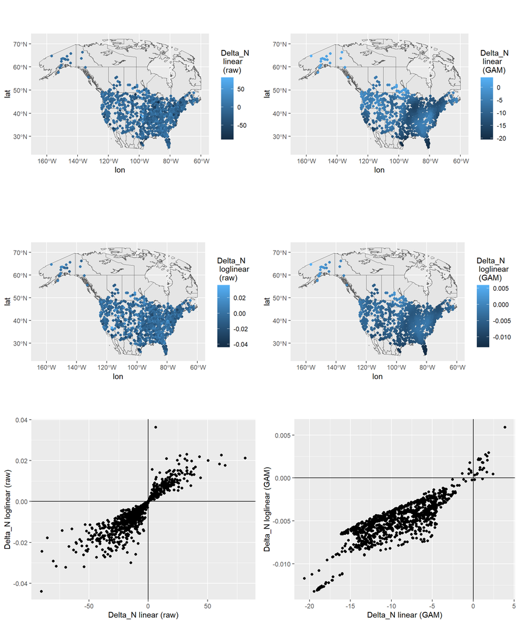

```r
#
p.deltaNgam <- ggplot(data=states) +
               geom_sf() +
               geom_point(data = routes, aes(x = lon,
                                             y = lat,
                                             colour = delta_N_PK_gam)) +
               scale_colour_continuous(name = "Delta_N \n linear   \n (GAM)")

p.deltaNgampois <- ggplot(data=states) +
                   geom_sf() +
                   geom_point(data = routes, aes(x = lon,
                                                 y = lat,
                                                 colour = delta_Npois_gam)) +
                   scale_colour_continuous(name = "Delta_N \n loglinear \n (GAM)")

p.deltaN <- ggplot(data=states) +
            geom_sf() +
            geom_point(data = routes, aes(x = lon,
                                          y = lat,
                                          colour = delta_N_PK)) +
            scale_colour_continuous(name = "Delta_N \n linear \n (raw)")

p.deltaNpois<- ggplot(data=states) +
               geom_sf() +
               geom_point(data = routes, aes(x = lon,
                                             y = lat,
                                             colour = delta_Npois_PK)) +
               scale_colour_continuous(name = "Delta_N \n loglinear \n (raw)")

N.gam.biplot <- ggplot(data=routes, aes(x= delta_N_PK_gam, y = delta_Npois_gam)) +
                geom_point() +
                xlab("Delta_N linear (GAM)") + ylab("Delta_N loglinear (GAM)")+
                geom_vline(xintercept=0) + geom_hline(yintercept=0)

N.biplot <- ggplot(data=routes, aes(x= delta_N_PK, y = delta_Npois_PK)) +
            geom_point() +
            xlab("Delta_N linear (raw)") + ylab("Delta_N loglinear (raw)")+
            geom_vline(xintercept=0) + geom_hline(yintercept=0)

grid.arrange(p.deltaN,  p.deltaNgam,
             p.deltaNpois,p.deltaNgampois,
             N.biplot,  N.gam.biplot,
             nrow=3, ncol=2)
```

# 8 Additional checks of metrics

Here we compare the rates derived from the mixed effect model (used in the main text) with values obtained from simple lm().

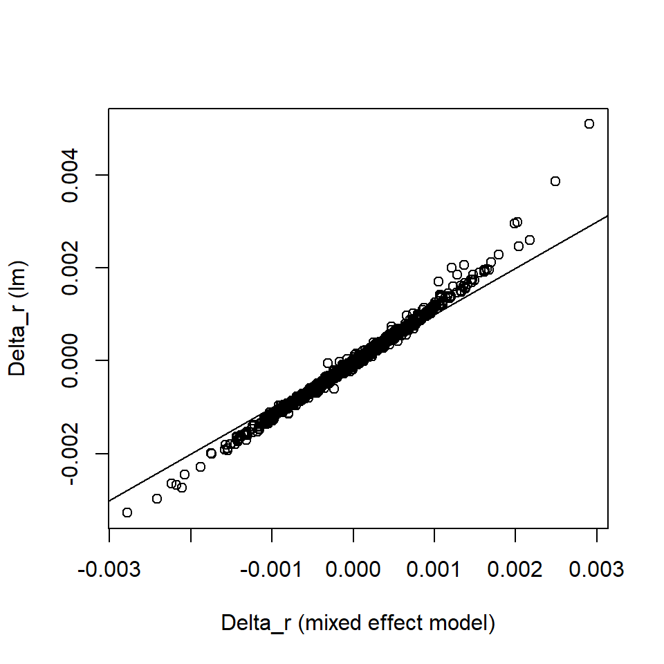

```r
plot(routes$delta_r, routes$delta_r_PK,
     xlab = "Delta_r (mixed effect model)", ylab="Delta_r (lm)")
abline(a=0, b=1)
```

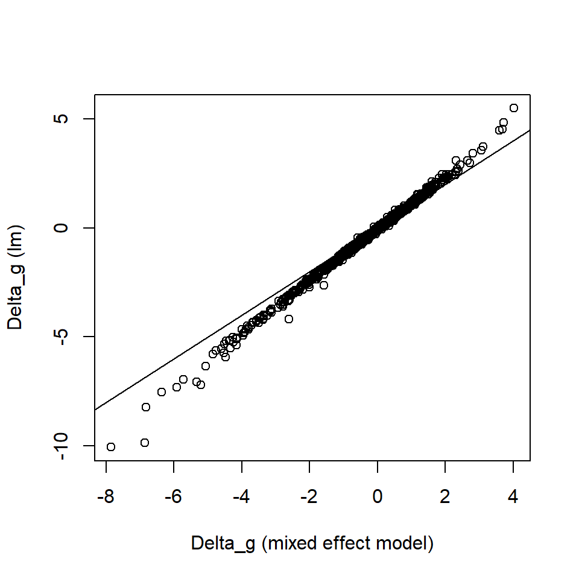

```r
plot(routes$delta_g, routes$delta_g_PK,
     xlab = "Delta_g (mixed effect model)", ylab="Delta_g (lm)")
abline(a=0, b=1)
```

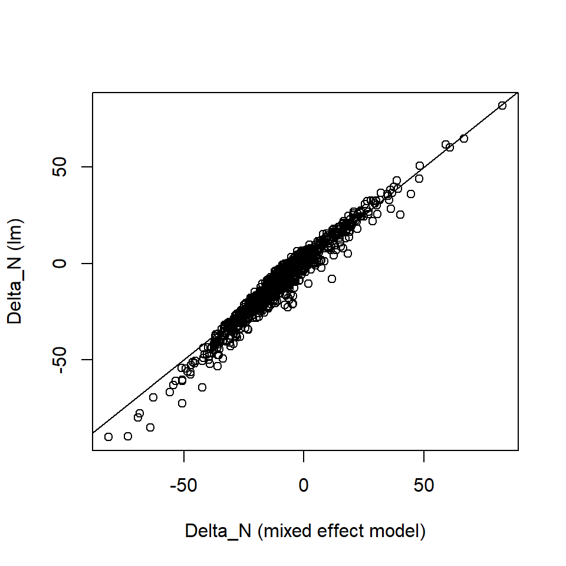

```r
plot(routes$delta_N, routes$delta_N_PK,
     xlab = "Delta_N (mixed effect model)", ylab="Delta_N (lm)")
abline(a=0, b=1)
```